# M.I.C.E. Encoding

01-23-18

## Experimental Design

### Overview

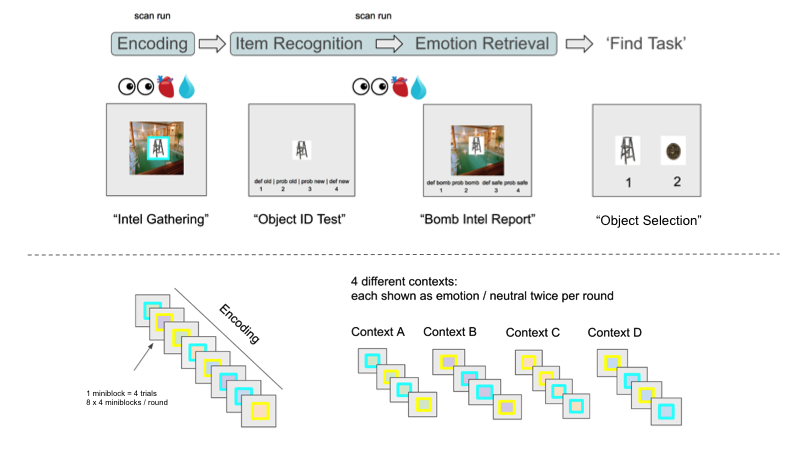

## Experimental Design

### Overview

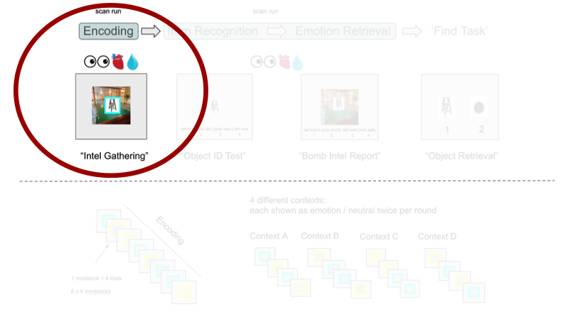

## Encoding Task

### Trial Overview

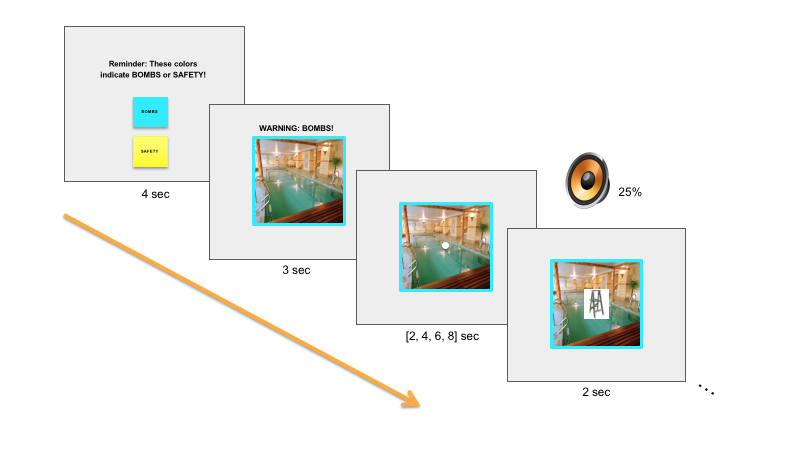

[video not shown]

## Hypotheses

- What are the *sustained* neural correlates supporting encoding in a threatening/safe context?
  - Caudate- Threat of shock (Collins et al., 2014; Murty, LaBar, Adcock, 2012)
  - Hippocampus
  - Others?
- What are the *transient* neural correlates supporting item-emotion encoding?
  - Amygdala (AMY) - emotional salience
  - Perirhinal cortex (PRC) - items and item features

## Modeling

To answer these questions, we created a GLM that:

- …captures both **sustained** BOLD responses over the course of Mini-blocks and **transient** BOLD responses to individual stimuli.
- …captures neural correlates that vary as a function of subsequent item-emotion memory (i.e., a **difference in memory** effect).

## Modeling

### Design Matrix

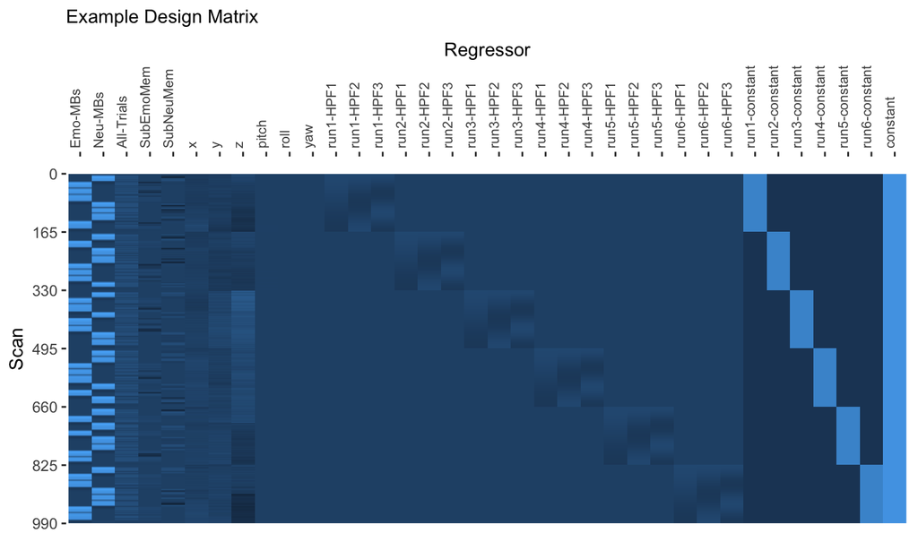

## Modeling

### DM Parametric Modulators

- *Negative* Subsequent Memory Score:
  - IFF bomb object:
    - Score 4: Def Bomb (i.e., HC Hit)
    - Score 3: Prob Bomb (i.e, LC Hit)
    - Score 2: Prob Safe (i.e., LC Miss)
    - Score 1: Def Safe (i.e., HC Miss)
  - IFF safe object:
    - Average Negative Subsequent Memory Score

## Modeling

### DM Parametric Modulators

- *Neutral* Subsequent Memory Score:
  - IFF safe object:
    - Score 4: Def Safe (i.e., HC Hit)
    - Score 3: Prob Safe (i.e., LC Hit)
    - Score 2: Prob Bomb (i.e., LC Miss)
    - Score 1: Def Bomb (i.e., HC Miss)
  - IFF bomb object:
    - Average Neutral Subsequent Memory Score

## Modeling

### DM Parametric Modulators

- Note: We dropped participants with < 10 non-high confidence emotional hits (def bomb | bomb) OR < 10 non-high confidence neutral hits (def safe | safe), leaving an **n = 18**. In other words, people were *really good* at this task.

## Modeling

### DM Parametric Modulators

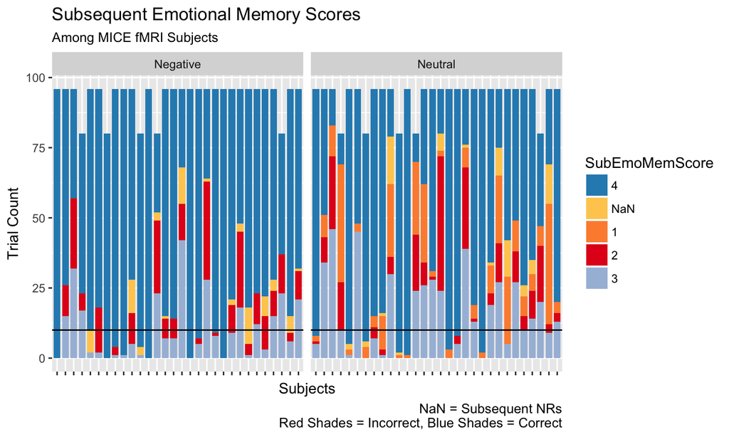

## Results

## Results

### Outline

- Transient DM Effects
  - MTL ROIs
  - Outside of MTL (Whole Brain)
- Sustained Effects
  - MTL ROIs
  - Outside of the MTL (Whole Brain)

## Results

### MTL ROIs

## Results

### Transient DM Effects

## Transient DM Effects

### MTL

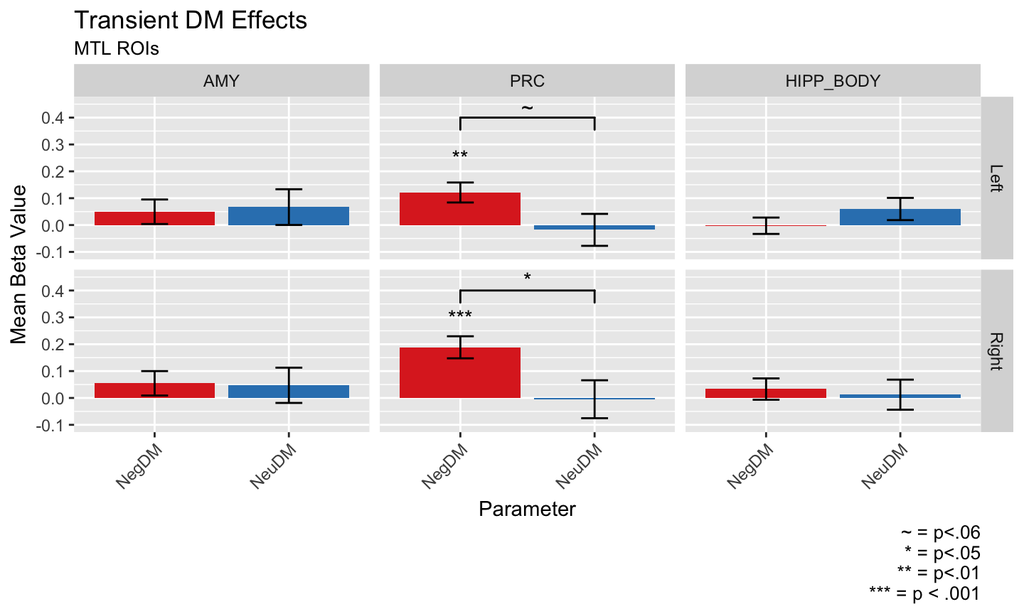

## Transient DM Effects

### Outside MTL

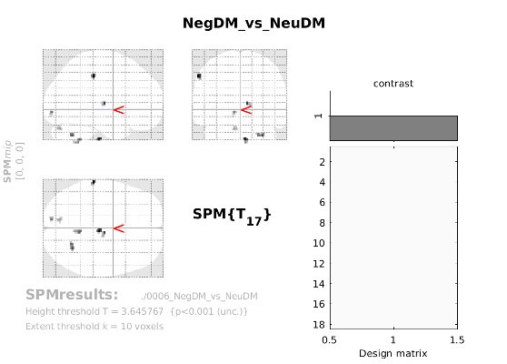

- Whole brain results; p<.001 (unc.) k=10
- Not much survives a liberal uncorrected threshold
- Small cerebellum, brainstem, early visual, and superior parietal (supramarginal gyrus?) clusters

## Results

### Sustained Encoding

## Sustained

### MTL

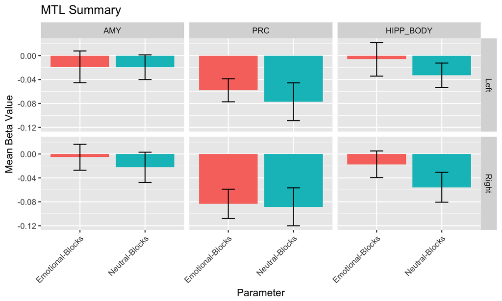

## Sustained

### Outside MTL

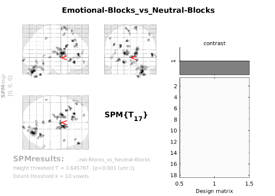

- Whole brain results; p<.001 (unc.) k=10

## Sustained

### Outside MTL

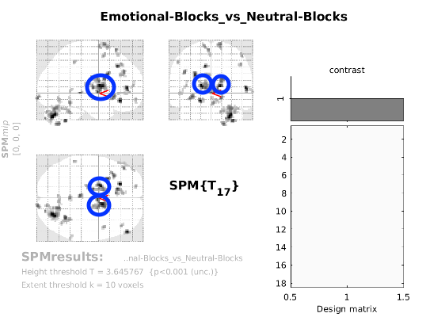

- Whole brain results; p<.001 (unc.) k=10
- Caudate!!

## Sustained

### Outside MTL

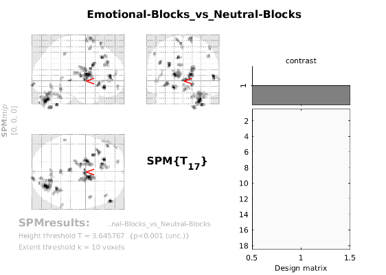

- Whole brain results; p<.001 (unc.) k=10
- Caudate!!
  - Specifically, looks like the Caudate Tail/posterior caudate
- Other brain regions include bilateral frontal pole, ACC, superior frontal gyrus, orbital frontal cortex, early visual, and the cerebellum

## Future analyses

- Functional connectivity
  - AMY <–> PRC?
- Other thoughts? Questions? Suggestions? Comments? Concearns?